### Simulating experiments

{% raw %}

```python
%matplotlib inline
%config InlineBackend.figure_format = 'retina'
```

{% endraw %} {% raw %}

`plot_rescorla_game`[[source]](https://github.com/hgzech/simulation_workshop/tree/master/simulation_workshop/simulation.py#L48)

> `plot_rescorla_game`(**`T`**, **`mu`**, **`alpha`**, **`beta`**)

{% endraw %} {% raw %}

{% endraw %} {% raw %}

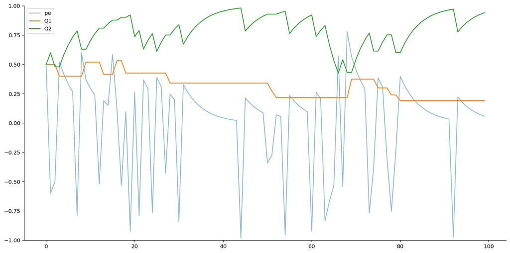

```python
T = 100 # number of trials
mu = [.2,.8] # reward probabilities
alpha = .2 # learning rate
beta = 4 # inverse temperature
plot_rescorla_game(T, mu, alpha, beta)
```

{% endraw %}

> Reducing the learning rate (participant does not manage to learn probabilities)

{% raw %}

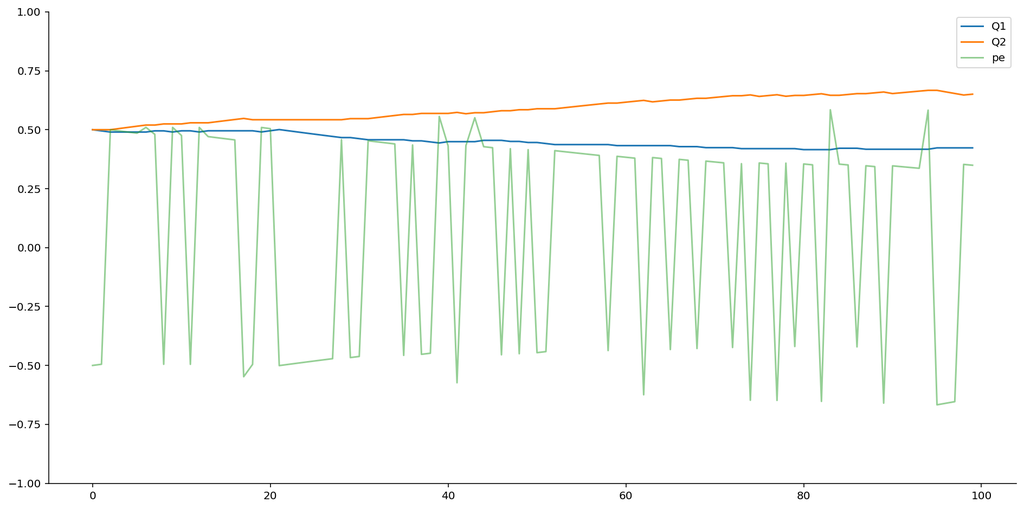

```python
T = 100 # number of trials
mu = [.2,.8] # reward probabilities
alpha = .01 # learning rate
beta = 4 # inverse temperature
plot_rescorla_game(T, mu, alpha, beta)
```

{% endraw %}

> Let's give them more trials

{% raw %}

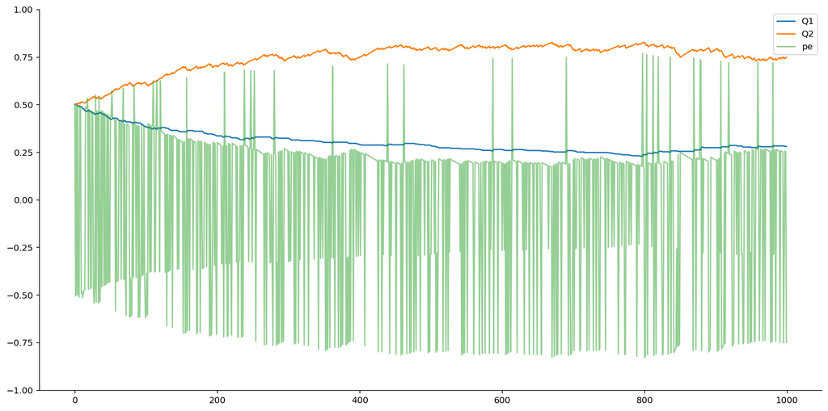

```python
T = 1000 # number of trials
mu = [.2,.8] # reward probabilities
alpha = .01 # learning rate
beta = 4 # inverse temperature
plot_rescorla_game(T, mu, alpha, beta)
```

{% endraw %}

> An extreme beta value makes participants stop exploring.

{% raw %}

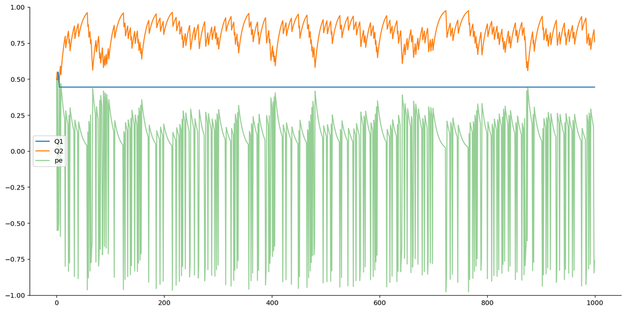

```python
T = 1000 # number of trials
mu = [.2,.8] # reward probabilities
alpha = .1 # learning rate
beta = 1000 # inverse temperature
plot_rescorla_game(T, mu, alpha, beta)
```

{% endraw %}

> If beta is very low, participants still learn, but they don't use that knowledge (something that we cannot see in this plot yet).

{% raw %}

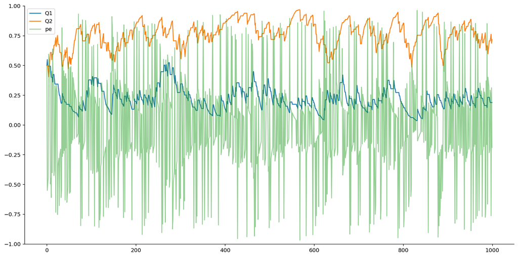

```python
T = 1000 # number of trials
mu = [.2,.8] # reward probabilities
alpha = .1 # learning rate
beta = .0000000001 # inverse temperature
plot_rescorla_game(T, mu, alpha, beta)
```

{% endraw %}

## Choice Kernel

In the choice kernel function, we remove the deltas.

{% raw %}

`simulate_M4ChoiceKernel_v1`[[source]](https://github.com/hgzech/simulation_workshop/tree/master/simulation_workshop/simulation.py#L62)

> `simulate_M4ChoiceKernel_v1`(**`T`**, **`mu`**, **`alpha_c`**, **`beta_c`**)

{% endraw %} {% raw %}

{% endraw %}

> Note that choice_kernel decays with the inverted alpha in each trial `choice_kernel = (1 - alpha_c) * choice_kernel`

{% raw %}

`plot_choice_kernel_game`[[source]](https://github.com/hgzech/simulation_workshop/tree/master/simulation_workshop/simulation.py#L81)

> `plot_choice_kernel_game`(**`T`**, **`mu`**, **`alpha`**, **`beta`**)

{% endraw %} {% raw %}

{% endraw %} {% raw %}

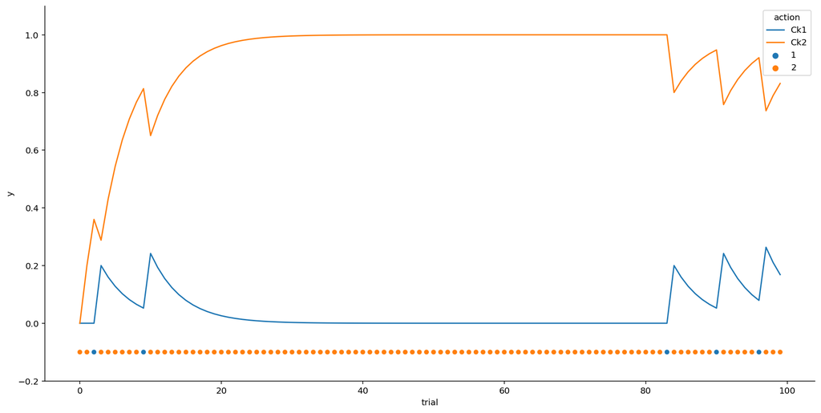

```python
T = 100 # number of trials
mu = [.2,.8] # reward probabilities
alpha = .2 # learning rate
beta = 4 # inverse temperature
actions = plot_choice_kernel_game(T, mu, alpha, beta)
```

{% endraw %} {% raw %}

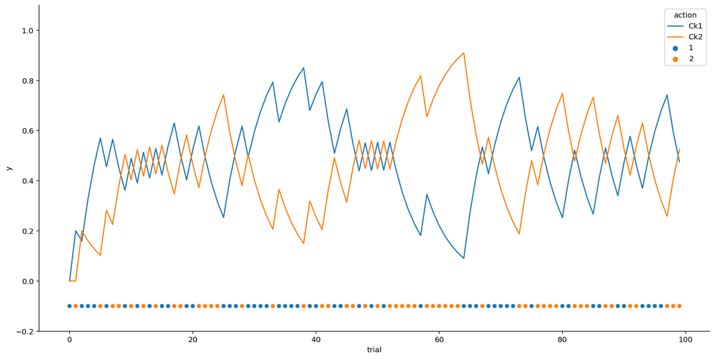

```python
T = 100 # number of trials
mu = [.2,.8] # reward probabilities
alpha = .2 # learning rate
beta = .004 # inverse temperature
actions = plot_choic_kernel_game(T, mu, alpha, beta)
```

{% endraw %} {% raw %}

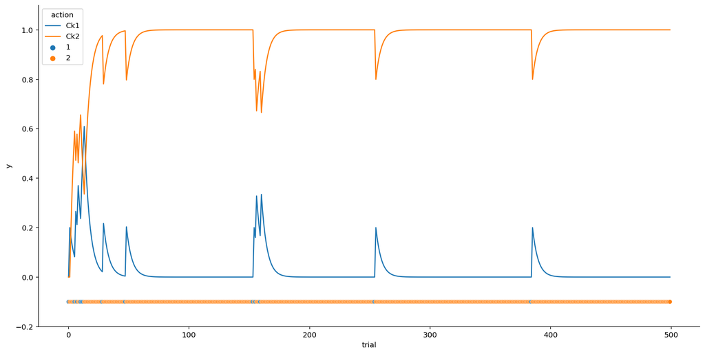

```python
T = 500 # number of trials
mu = [.2,.8] # reward probabilities
alpha = .2 # learning rate
beta = 4 # inverse temperature
actions = plot_choic_kernel_game(T, mu, alpha, beta)
```

{% endraw %}

> With a reasonably high beta one of the options should always move towards 1.